# Homework 6

Mario Perales

March 2 2016

*Source file* ⇒ Stats133HW6.Rmd

# 1

```r
is_leap_year <- function(year) {
  ((year %% 4 == 0 & year %% 100 != 0) | year %% 400 == 0)
}
```

Now we do a simple *while* loop on our function while incrementing our initial year (i.e. birth year) until we reach our current year (2016). Everytime we encounter a leap year, we tally up the total of leap years so far:

```r
  year = 1994
  number_of_leap_years = 0
  while(year <= 2016) {
    if(is_leap_year(year)){
      number_of_leap_years = number_of_leap_years + 1
    }
    year = year + 1
  }
  print(number_of_leap_years)
```

```
## [1] 6
```

# 2

## a

As suggested, we create two vectors, **x** and **y** sampled from the Uniform Distribution between -1 and 1. Next, we check if the magnitude of **(x,y)** is less than or equal to one, implying the point **(x,y)** is in the unit circle. We do this by a simple boolean operator.

We then add up the total number of points in the unit circle (which is easy since boolean values evaluate to 1 or 0) and divide that by the total number of points we are sampling to get our desired proportion.

Finally, we create a data frame with the variables **x**,**y** and **in_unit_circle** so we can plot it in ggplot. We make the *col* aesthetic to correspond to the variable **in_the_unit_crcle** and change up a few things about the legend to make it look nicer.

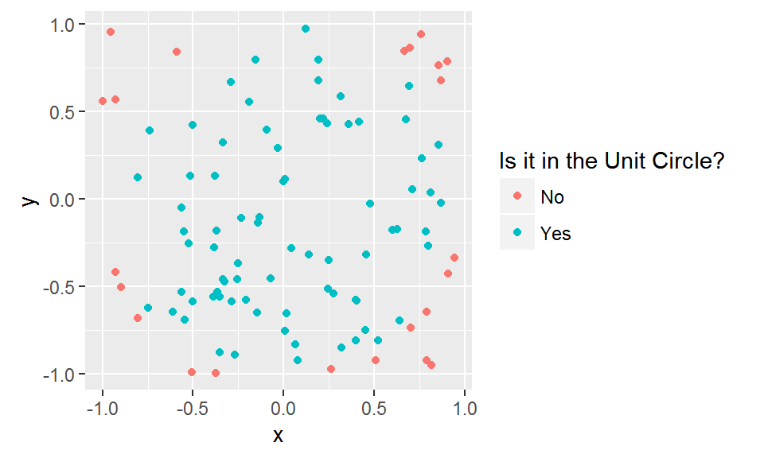

```r
  x = runif(100,-1,1)
  y = runif(100,-1,1)

  in_unit_circle <-
    x^2 + y^2 <= 1

  x_y = data.frame(x,y,in_unit_circle)

  proportion = sum(x_y$in_unit_circle)/100

  ggplot(data = x_y, aes(x = x, y = y, color = in_unit_circle)) +
    geom_point() +
    scale_color_discrete(name = "Is it in the Unit Circle?",
                         breaks = c("FALSE", "TRUE"),
                         labels = c("No", "Yes"))
```

```r
  approximate_area = proportion*4
  print(approximate_area)
```

```
## [1] 3.08
```

## b

We essentially replicate our code from before but this time we replace 100 with **n** and use that a function argument. We also set **plotit** to be false so that it does not plot all the samples when we later use the *replicate* function.

For the sake of checking, we do the same thing as part a and essentially get the same thing (but slightly different values due to the *runif* function)

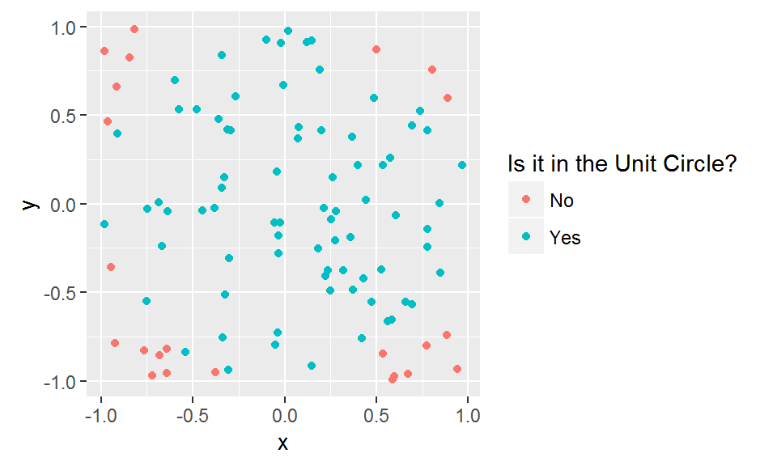

```
## [1] 3.08
```

```r
  our_function <- function(n = 100,plotit = FALSE){
    x = runif(n,-1,1)
    y = runif(n,-1,1)
    in_unit_circle <-
      x^2 + y^2 <= 1

    x_y <- data.frame(x,y,in_unit_circle)

    proportion = sum(x_y$in_unit_circle)/n

    if(plotit) {
      plot <-
        ggplot(data = x_y, aes(x = x, y = y, color = in_unit_circle)) +
        geom_point() +
        scale_color_discrete(name = "Is it in the Unit Circle?",
                           breaks = c("FALSE", "TRUE"),
                           labels = c("No", "Yes"))
      print(plot)
    }
    approximate_area = proportion*4
    return(approximate_area)
  }

  our_function(100,TRUE)
```

## c & d

Essentially the same thing, the only thing we change is that we create a data frame which contains the area approximation, as well as the corresponding vector_size. We combine both components into a data frame and plot with via ggplot. In ggplot, we use the appropriate functions to label, color, and plot our data:

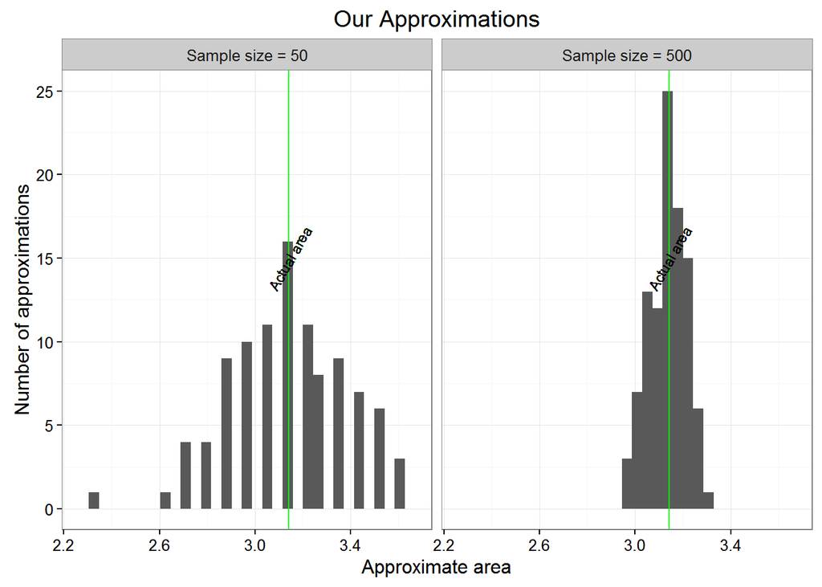

```r
  first_approx = replicate(100,our_function(50))
  second_approx = replicate(100,our_function(500))
  vector_size1 = replicate(100,"Sample size = 50")
  vector_size2 = replicate(100,"Sample size = 500")

  approx = first_approx
  vector_size = vector_size1

  df <- data.frame(approx,vector_size)
  df2 <- df
  df2$approx = second_approx
  df2$vector_size = vector_size2

  df = rbind(df,df2)

  df %>%
    ggplot(aes(approx)) +
    geom_histogram() +
    facet_grid(. ~ vector_size) +
    geom_vline(xintercept = pi, color = "green") +
    geom_text(aes(x = pi, y = 15, label = "Actual area"), angle = 60, size = 3) +
    labs(title = "Our Approximations", x = "Approximate area", y = "Number of approximations") +
    theme_bw()
```

# 3

## a

Basically copying the method gives us this. Also note that we initialize the functions *inside* our method as per instructions. We use the **tol** to help us know when to stop our function (via a while loop).

Lastly, we indeed do verify that our function finds the root.

```r
Newton_method1 <- function(init_guess, tol)  {
  x = init_guess
  fx = x^3 + 2*x^2 - 7
  while(abs(fx) > tol){
    fpx = 3*x^2 + 4*x
    x = x - fx/fpx
    fx = x^3 + 2*x^2 - 7
  }
  return(x)
}

Newton_method1(-2,.00001)
```

```
## [1] 1.428818
```

## b

Pretty self-explanatory. We just create the functions and save them to variables for later use (both inputs are a value x).

```r
f <- function(x) {
  return(x^3+2*x^2-7)
}

fpx <- function(x) {
  return(3*x^2 + 4*x)
}
```

## c

Literally the same thing as part a, the only difference is we eliminate any time we initialized our functions (since we did it outside of the function). Note that we also take functions as our input values as well.

```r
Newton_method2 <- function(g,gpx,init_guess,tol) {
  x = init_guess
  while(abs(g(x)) > tol) {
    x = x - g(x)/gpx(x)
  }
  return(x)
}

Newton_method2(f,fpx,-2,.00001)
```

```
## [1] 1.428818
```

## d

For our final segment, we basically test our method with the function -x^4 + 8*x^2 + 4, which has a root at x = 2.910693380457 (according to Wolfram Alpha). Thus we write the corresponding functions for it and plug it into our method. We then print our approximate root to see how it fairs!

Lastly, we plot the function on the interval -3 to 3. Again, we use ggplot for this and to plot our guess of where the root is.

```r
hx <- function(x) {
  return(-x^4 + 8*x^2 + 4)
}

hpx <- function(x) {
  return(-4*x^3 + 16*x)
}

xseq <- seq(-3, 3, length = 100)
yseq <- hx(xseq)
df <- data.frame(xseq,yseq)
our_plot <- df %>% ggplot(aes(xseq,yseq)) + geom_line(stat = "identity", col = "red")
our_root = Newton_method2(hx,hpx,3,.00001)
print(our_root)
```

```
## [1] 2.910693
```

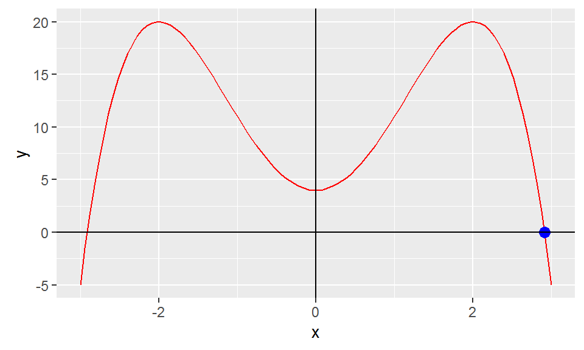

```r
our_plot + geom_point(x = our_root, y = hx(our_root), col = "blue", size = 3) +
  geom_hline(yintercept = 0) +
  geom_vline(xintercept = 0) +
  labs(x = "x", y = "y")
```

We are really really close! Looks like our method worked.